# (노트) 판다스 백엔드 플랏

#### 예제2 (plotly)

`-` 다시 tips예제로 돌아오자.

```python
df = px.data.tips()
df
```

|  | total_bill | tip | sex | smoker | day | time | size |
| --- | --- | --- | --- | --- | --- | --- | --- |
| 0 | 16.99 | 1.01 | Female | No | Sun | Dinner | 2 |
| 1 | 10.34 | 1.66 | Male | No | Sun | Dinner | 3 |
| 2 | 21.01 | 3.50 | Male | No | Sun | Dinner | 3 |
| 3 | 23.68 | 3.31 | Male | No | Sun | Dinner | 2 |
| 4 | 24.59 | 3.61 | Female | No | Sun | Dinner | 4 |
| ... | ... | ... | ... | ... | ... | ... | ... |
| 239 | 29.03 | 5.92 | Male | No | Sat | Dinner | 3 |
| 240 | 27.18 | 2.00 | Female | Yes | Sat | Dinner | 2 |
| 241 | 22.67 | 2.00 | Male | Yes | Sat | Dinner | 2 |
| 242 | 17.82 | 1.75 | Male | No | Sat | Dinner | 2 |
| 243 | 18.78 | 3.00 | Female | No | Thur | Dinner | 2 |

244 rows × 7 columns

`-` 성별에 따라서 팁을 주는게다른지? (박스플랏대신에 히스토그램그램을 그려도 분포를 잘 볼 수 있다.)

```python
fig = df.plot.hist(x='total_bill',backend='plotly',color='sex',facet_col='sex',width=1000,height=600)
show(fig)
```

[interactive chart not shown]

- 빈도 자체도 보여서 (남성이 더 횟수자체가 많음) 더 유익한플랏

`-` 시간에 따라서도 다른지?

```python
fig = df.plot.hist(x='total_bill',backend='plotly',facet_row='sex',facet_col='time',color='sex',width=1000,height=600)
show(fig)
```

[interactive chart not shown]

- tidydata가 확실히 한번 만들어두면 그리기 편리함

### area

`-` 주류플랏은 아님

`-` 그래도 그려달라는 사람이 있었음

#### 예제1 (matplotlib)

`-` 다시 핸드폰예제

```python
df = pd.read_csv('https://raw.githubusercontent.com/kalilurrahman/datasets/main/mobilephonemktshare2020.csv')
df
```

|  | Date | Samsung | Apple | Huawei | Xiaomi | Oppo | Mobicel | Motorola | LG | Others | Realme | Google | Nokia | Lenovo | OnePlus | Sony | Asus |
| --- | --- | --- | --- | --- | --- | --- | --- | --- | --- | --- | --- | --- | --- | --- | --- | --- | --- |
| 0 | 2019-10 | 31.49 | 22.09 | 10.02 | 7.79 | 4.10 | 3.15 | 2.41 | 2.40 | 9.51 | 0.54 | 2.35 | 0.95 | 0.96 | 0.70 | 0.84 | 0.74 |
| 1 | 2019-11 | 31.36 | 22.90 | 10.18 | 8.16 | 4.42 | 3.41 | 2.40 | 2.40 | 9.10 | 0.78 | 0.66 | 0.97 | 0.97 | 0.73 | 0.83 | 0.75 |
| 2 | 2019-12 | 31.37 | 24.79 | 9.95 | 7.73 | 4.23 | 3.19 | 2.50 | 2.54 | 8.13 | 0.84 | 0.75 | 0.90 | 0.87 | 0.74 | 0.77 | 0.70 |
| 3 | 2020-01 | 31.29 | 24.76 | 10.61 | 8.10 | 4.25 | 3.02 | 2.42 | 2.40 | 7.55 | 0.88 | 0.69 | 0.88 | 0.86 | 0.79 | 0.80 | 0.69 |
| 4 | 2020-02 | 30.91 | 25.89 | 10.98 | 7.80 | 4.31 | 2.89 | 2.36 | 2.34 | 7.06 | 0.89 | 0.70 | 0.81 | 0.77 | 0.78 | 0.80 | 0.69 |
| 5 | 2020-03 | 30.80 | 27.03 | 10.70 | 7.70 | 4.30 | 2.87 | 2.35 | 2.28 | 6.63 | 0.93 | 0.73 | 0.72 | 0.74 | 0.78 | 0.76 | 0.66 |
| 6 | 2020-04 | 30.41 | 28.79 | 10.28 | 7.60 | 4.20 | 2.75 | 2.51 | 2.28 | 5.84 | 0.90 | 0.75 | 0.69 | 0.71 | 0.80 | 0.76 | 0.70 |
| 7 | 2020-05 | 30.18 | 26.72 | 10.39 | 8.36 | 4.70 | 3.12 | 2.46 | 2.19 | 6.31 | 1.04 | 0.70 | 0.73 | 0.77 | 0.81 | 0.78 | 0.76 |
| 8 | 2020-06 | 31.06 | 25.26 | 10.69 | 8.55 | 4.65 | 3.18 | 2.57 | 2.11 | 6.39 | 1.04 | 0.68 | 0.74 | 0.75 | 0.77 | 0.78 | 0.75 |
| 9 | 2020-07 | 30.95 | 24.82 | 10.75 | 8.94 | 4.69 | 3.46 | 2.45 | 2.03 | 6.41 | 1.13 | 0.65 | 0.76 | 0.74 | 0.76 | 0.75 | 0.72 |
| 10 | 2020-08 | 31.04 | 25.15 | 10.73 | 8.90 | 4.69 | 3.38 | 2.39 | 1.96 | 6.31 | 1.18 | 0.63 | 0.74 | 0.72 | 0.75 | 0.73 | 0.70 |
| 11 | 2020-09 | 30.57 | 24.98 | 10.58 | 9.49 | 4.94 | 3.50 | 2.27 | 1.88 | 6.12 | 1.45 | 0.63 | 0.74 | 0.67 | 0.81 | 0.69 | 0.67 |
| 12 | 2020-10 | 30.25 | 26.53 | 10.44 | 9.67 | 4.83 | 2.54 | 2.21 | 1.79 | 6.04 | 1.55 | 0.63 | 0.69 | 0.65 | 0.85 | 0.67 | 0.64 |

`-` 점유율을 에어리어 플랏으로

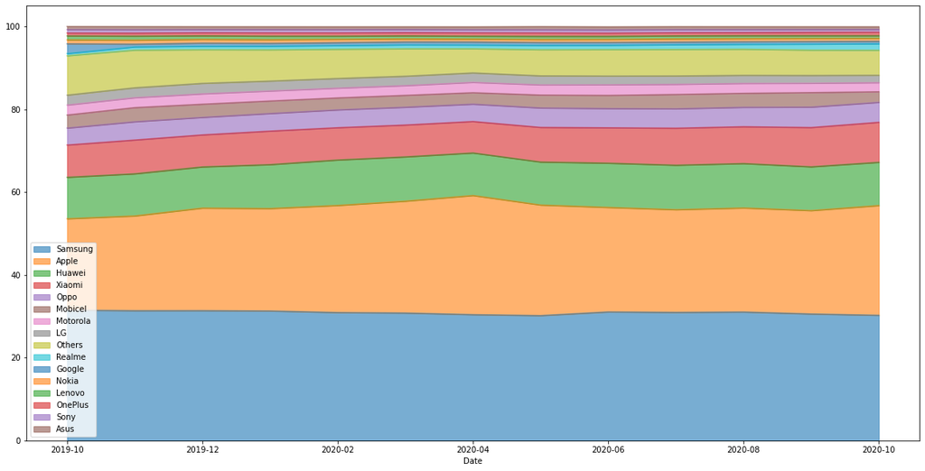

```python
df.plot.area(x='Date',figsize=(20,10),alpha=0.6)
```

- stacked version의 박스플랏보다는 좋은것 같다.

#### 예제1 (plotly)

`-` plotly를 쓰기 위해서 tidydata로 바꾸자.

```python
df.melt(id_vars='Date')
```

|  | Date | variable | value |
| --- | --- | --- | --- |
| 0 | 2019-10 | Samsung | 31.49 |
| 1 | 2019-11 | Samsung | 31.36 |
| 2 | 2019-12 | Samsung | 31.37 |
| 3 | 2020-01 | Samsung | 31.29 |
| 4 | 2020-02 | Samsung | 30.91 |
| ... | ... | ... | ... |
| 203 | 2020-06 | Asus | 0.75 |
| 204 | 2020-07 | Asus | 0.72 |
| 205 | 2020-08 | Asus | 0.70 |
| 206 | 2020-09 | Asus | 0.67 |
| 207 | 2020-10 | Asus | 0.64 |

208 rows × 3 columns

```python
fig= df.melt(id_vars='Date').plot.area(x='Date',y='value',color='variable',backend='plotly',width=600,height=500)
show(fig)
```

[interactive chart not shown]

- 사실 범주클릭기능이 진짜 좋아요
- 내가 시각화를 잘하는 이유:
  - 먹고살기 위해서 외웠어요.
  - 발표를 위해서 시각화하여 슬라이드로 발표했는데 발표자료에 없는 시각화를 요구할때가 많았음.
  - 예를들어 2020년에 무슨 삼성에서 신제품이 나왔다면 그때 이전과 이후로 나누어서 점유율을 시각화 해달라든지?
  - --> 빨리그려줘야했는데 tidydata / untidydata 를 모두 잘쓰고 (대부분 이 개념조차 없음) 데이터프레임을 빨리 변형할 수 있는 사람이 없었음
  - --> 저도 잘 못했는데 배웠어요 (항상외우고다니진 않음 발표전에만 몇개 연습해보면서 외움)
  - --> 젤 큰 무기는 판다스 백엔드 + 플롯틀리 + 지지플랏
- 시각화 잘하면 예쁨받음
  - 순간적으로 빠르게 그리는게 생각보다 쉽지 않음
  - 시각화는 분석의 주인공보다 서포트하는 역할.
  - 처음에 갑자기 분석의 주인공이 되는게 좀 부담스러웠음.
  - 시각화를 잘하면 여기저기서 인기 많았음

#### 예제2 (matplotlib)

`-` 위키의 테이블 크롤링. 검색어 "대한민국의 인구수"

```python
df=pd.read_html('https://ko.wikipedia.org/wiki/%EB%8C%80%ED%95%9C%EB%AF%BC%EA%B5%AD%EC%9D%98_%EC%9D%B8%EA%B5%AC')[19]
df
```

|  | 행정구역별 | 2021. 06 비율 | 2021. 06 인구 | 2015 비율 | 2015 인구 | 2010 비율 | 2010 인구 | 2005 비율 | 2005 인구 | 2000 비율 | 2000 인구 |
| --- | --- | --- | --- | --- | --- | --- | --- | --- | --- | --- | --- |
| 0 | 전국 | 16.7 | 8652198 | 13.1 | 6775101 | 10.9 | 5506352 | 8.9 | 4324524 | 7.0 | 3355614 |
| 1 | 서울특별시 | 16.4 | 1568769 | 12.6 | 1262436 | 9.7 | 1002770 | 7.2 | 731349 | 5.4 | 558566 |
| 2 | 부산광역시 | 19.8 | 666644 | 14.6 | 514630 | 11.3 | 401784 | 8.3 | 302784 | 6.0 | 229075 |
| 3 | 대구광역시 | 17.0 | 408235 | 12.7 | 316122 | 10.0 | 252084 | 7.8 | 195419 | 5.9 | 149045 |
| 4 | 인천광역시 | 14.4 | 422658 | 10.7 | 312905 | 8.6 | 237805 | 6.9 | 178602 | 5.4 | 138316 |
| 5 | 광주광역시 | 14.5 | 208879 | 11.3 | 166389 | 9.0 | 130457 | 7.1 | 99389 | 5.6 | 77325 |
| 6 | 대전광역시 | 14.8 | 215997 | 10.9 | 165528 | 8.7 | 130245 | 6.9 | 99811 | 5.5 | 75769 |
| 7 | 울산광역시 | 13.1 | 147811 | 8.8 | 103205 | 6.8 | 76800 | 5.3 | 57797 | 4.0 | 42119 |
| 8 | 세종특별자치시 | 10.0 | 36194 | 10.6 | 22399 | - | - | - | - | - | - |
| 9 | 경기도 | 13.5 | 1825846 | 10.5 | 1318882 | 8.7 | 1022456 | 7.1 | 755511 | 5.7 | 524807 |
| 10 | 강원도 | 21.2 | 325579 | 16.9 | 261671 | 14.8 | 226505 | 12.1 | 183471 | 9.3 | 143945 |
| 11 | 충청북도 | 18.4 | 294530 | 14.8 | 234813 | 13.2 | 204470 | 11.3 | 168670 | 9.1 | 136160 |
| 12 | 충청남도 | 19.5 | 412504 | 16.4 | 341214 | 14.9 | 308556 | 13.3 | 261800 | 11.2 | 215059 |
| 13 | 전라북도 | 21.8 | 391178 | 17.8 | 333524 | 15.2 | 284373 | 12.9 | 243721 | 10.3 | 205807 |
| 14 | 전라남도 | 23.9 | 440014 | 20.5 | 391837 | 18.3 | 350900 | 15.6 | 306439 | 11.9 | 254370 |
| 15 | 경상북도 | 22.2 | 585088 | 17.7 | 479634 | 15.6 | 418858 | 13.4 | 360068 | 10.7 | 300614 |
| 16 | 경상남도 | 17.9 | 594154 | 13.8 | 464019 | 11.8 | 388648 | 10.2 | 323898 | 8.4 | 261303 |
| 17 | 제주특별자치도 | 16.0 | 108118 | 13.8 | 85893 | 12.2 | 69641 | 10.0 | 55795 | 8.0 | 43334 |

- 페이지에서 19번째 테이블
- 끔직할 정도로 타이디하지 않은 자료

`-` 첫번째 row는 일단 제외해야겠음

```python
df.iloc[1:]
```

|  | 행정구역별 | 2021. 06 비율 | 2021. 06 인구 | 2015 비율 | 2015 인구 | 2010 비율 | 2010 인구 | 2005 비율 | 2005 인구 | 2000 비율 | 2000 인구 |
| --- | --- | --- | --- | --- | --- | --- | --- | --- | --- | --- | --- |
| 1 | 서울특별시 | 16.4 | 1568769 | 12.6 | 1262436 | 9.7 | 1002770 | 7.2 | 731349 | 5.4 | 558566 |
| 2 | 부산광역시 | 19.8 | 666644 | 14.6 | 514630 | 11.3 | 401784 | 8.3 | 302784 | 6.0 | 229075 |
| 3 | 대구광역시 | 17.0 | 408235 | 12.7 | 316122 | 10.0 | 252084 | 7.8 | 195419 | 5.9 | 149045 |
| 4 | 인천광역시 | 14.4 | 422658 | 10.7 | 312905 | 8.6 | 237805 | 6.9 | 178602 | 5.4 | 138316 |
| 5 | 광주광역시 | 14.5 | 208879 | 11.3 | 166389 | 9.0 | 130457 | 7.1 | 99389 | 5.6 | 77325 |
| 6 | 대전광역시 | 14.8 | 215997 | 10.9 | 165528 | 8.7 | 130245 | 6.9 | 99811 | 5.5 | 75769 |
| 7 | 울산광역시 | 13.1 | 147811 | 8.8 | 103205 | 6.8 | 76800 | 5.3 | 57797 | 4.0 | 42119 |
| 8 | 세종특별자치시 | 10.0 | 36194 | 10.6 | 22399 | - | - | - | - | - | - |
| 9 | 경기도 | 13.5 | 1825846 | 10.5 | 1318882 | 8.7 | 1022456 | 7.1 | 755511 | 5.7 | 524807 |
| 10 | 강원도 | 21.2 | 325579 | 16.9 | 261671 | 14.8 | 226505 | 12.1 | 183471 | 9.3 | 143945 |
| 11 | 충청북도 | 18.4 | 294530 | 14.8 | 234813 | 13.2 | 204470 | 11.3 | 168670 | 9.1 | 136160 |
| 12 | 충청남도 | 19.5 | 412504 | 16.4 | 341214 | 14.9 | 308556 | 13.3 | 261800 | 11.2 | 215059 |
| 13 | 전라북도 | 21.8 | 391178 | 17.8 | 333524 | 15.2 | 284373 | 12.9 | 243721 | 10.3 | 205807 |
| 14 | 전라남도 | 23.9 | 440014 | 20.5 | 391837 | 18.3 | 350900 | 15.6 | 306439 | 11.9 | 254370 |
| 15 | 경상북도 | 22.2 | 585088 | 17.7 | 479634 | 15.6 | 418858 | 13.4 | 360068 | 10.7 | 300614 |
| 16 | 경상남도 | 17.9 | 594154 | 13.8 | 464019 | 11.8 | 388648 | 10.2 | 323898 | 8.4 | 261303 |
| 17 | 제주특별자치도 | 16.0 | 108118 | 13.8 | 85893 | 12.2 | 69641 | 10.0 | 55795 | 8.0 | 43334 |

`-` 일단 스택을 해보자.

```python
df.iloc[1:].stack()
```

|  |  | 2000 | 2005 | 2010 | 2015 | 2021. 06 | 행정구역별 |
| --- | --- | --- | --- | --- | --- | --- | --- |
| 1 | 비율 | 5.4 | 7.2 | 9.7 | 12.6 | 16.4 | NaN |
|  | 인구 | 558566 | 731349 | 1002770 | 1262436.0 | 1568769.0 | NaN |
|  | 행정구역별 | NaN | NaN | NaN | NaN | NaN | 서울특별시 |
| 2 | 비율 | 6.0 | 8.3 | 11.3 | 14.6 | 19.8 | NaN |
|  | 인구 | 229075 | 302784 | 401784 | 514630.0 | 666644.0 | NaN |
|  | 행정구역별 | NaN | NaN | NaN | NaN | NaN | 부산광역시 |
| 3 | 비율 | 5.9 | 7.8 | 10.0 | 12.7 | 17.0 | NaN |
|  | 인구 | 149045 | 195419 | 252084 | 316122.0 | 408235.0 | NaN |
|  | 행정구역별 | NaN | NaN | NaN | NaN | NaN | 대구광역시 |
| 4 | 비율 | 5.4 | 6.9 | 8.6 | 10.7 | 14.4 | NaN |
|  | 인구 | 138316 | 178602 | 237805 | 312905.0 | 422658.0 | NaN |
|  | 행정구역별 | NaN | NaN | NaN | NaN | NaN | 인천광역시 |
| 5 | 비율 | 5.6 | 7.1 | 9.0 | 11.3 | 14.5 | NaN |
|  | 인구 | 77325 | 99389 | 130457 | 166389.0 | 208879.0 | NaN |
|  | 행정구역별 | NaN | NaN | NaN | NaN | NaN | 광주광역시 |
| 6 | 비율 | 5.5 | 6.9 | 8.7 | 10.9 | 14.8 | NaN |
|  | 인구 | 75769 | 99811 | 130245 | 165528.0 | 215997.0 | NaN |
|  | 행정구역별 | NaN | NaN | NaN | NaN | NaN | 대전광역시 |
| 7 | 비율 | 4.0 | 5.3 | 6.8 | 8.8 | 13.1 | NaN |
|  | 인구 | 42119 | 57797 | 76800 | 103205.0 | 147811.0 | NaN |
|  | 행정구역별 | NaN | NaN | NaN | NaN | NaN | 울산광역시 |
| 8 | 비율 | - | - | - | 10.6 | 10.0 | NaN |
|  | 인구 | - | - | - | 22399.0 | 36194.0 | NaN |
|  | 행정구역별 | NaN | NaN | NaN | NaN | NaN | 세종특별자치시 |
| 9 | 비율 | 5.7 | 7.1 | 8.7 | 10.5 | 13.5 | NaN |
|  | 인구 | 524807 | 755511 | 1022456 | 1318882.0 | 1825846.0 | NaN |
|  | 행정구역별 | NaN | NaN | NaN | NaN | NaN | 경기도 |
| 10 | 비율 | 9.3 | 12.1 | 14.8 | 16.9 | 21.2 | NaN |
|  | 인구 | 143945 | 183471 | 226505 | 261671.0 | 325579.0 | NaN |
|  | 행정구역별 | NaN | NaN | NaN | NaN | NaN | 강원도 |
| 11 | 비율 | 9.1 | 11.3 | 13.2 | 14.8 | 18.4 | NaN |
|  | 인구 | 136160 | 168670 | 204470 | 234813.0 | 294530.0 | NaN |
|  | 행정구역별 | NaN | NaN | NaN | NaN | NaN | 충청북도 |
| 12 | 비율 | 11.2 | 13.3 | 14.9 | 16.4 | 19.5 | NaN |
|  | 인구 | 215059 | 261800 | 308556 | 341214.0 | 412504.0 | NaN |
|  | 행정구역별 | NaN | NaN | NaN | NaN | NaN | 충청남도 |
| 13 | 비율 | 10.3 | 12.9 | 15.2 | 17.8 | 21.8 | NaN |
|  | 인구 | 205807 | 243721 | 284373 | 333524.0 | 391178.0 | NaN |
|  | 행정구역별 | NaN | NaN | NaN | NaN | NaN | 전라북도 |
| 14 | 비율 | 11.9 | 15.6 | 18.3 | 20.5 | 23.9 | NaN |
|  | 인구 | 254370 | 306439 | 350900 | 391837.0 | 440014.0 | NaN |
|  | 행정구역별 | NaN | NaN | NaN | NaN | NaN | 전라남도 |
| 15 | 비율 | 10.7 | 13.4 | 15.6 | 17.7 | 22.2 | NaN |
|  | 인구 | 300614 | 360068 | 418858 | 479634.0 | 585088.0 | NaN |
|  | 행정구역별 | NaN | NaN | NaN | NaN | NaN | 경상북도 |
| 16 | 비율 | 8.4 | 10.2 | 11.8 | 13.8 | 17.9 | NaN |
|  | 인구 | 261303 | 323898 | 388648 | 464019.0 | 594154.0 | NaN |
|  | 행정구역별 | NaN | NaN | NaN | NaN | NaN | 경상남도 |
| 17 | 비율 | 8.0 | 10.0 | 12.2 | 13.8 | 16.0 | NaN |
|  | 인구 | 43334 | 55795 | 69641 | 85893.0 | 108118.0 | NaN |
|  | 행정구역별 | NaN | NaN | NaN | NaN | NaN | 제주특별자치도 |

- 엉망임

`-` 인덱스를 설정하고 스택하자.

```python
df.iloc[1:]
```

|  | 행정구역별 | 2021. 06 비율 | 2021. 06 인구 | 2015 비율 | 2015 인구 | 2010 비율 | 2010 인구 | 2005 비율 | 2005 인구 | 2000 비율 | 2000 인구 |
| --- | --- | --- | --- | --- | --- | --- | --- | --- | --- | --- | --- |
| 1 | 서울특별시 | 16.4 | 1568769 | 12.6 | 1262436 | 9.7 | 1002770 | 7.2 | 731349 | 5.4 | 558566 |
| 2 | 부산광역시 | 19.8 | 666644 | 14.6 | 514630 | 11.3 | 401784 | 8.3 | 302784 | 6.0 | 229075 |
| 3 | 대구광역시 | 17.0 | 408235 | 12.7 | 316122 | 10.0 | 252084 | 7.8 | 195419 | 5.9 | 149045 |
| 4 | 인천광역시 | 14.4 | 422658 | 10.7 | 312905 | 8.6 | 237805 | 6.9 | 178602 | 5.4 | 138316 |
| 5 | 광주광역시 | 14.5 | 208879 | 11.3 | 166389 | 9.0 | 130457 | 7.1 | 99389 | 5.6 | 77325 |
| 6 | 대전광역시 | 14.8 | 215997 | 10.9 | 165528 | 8.7 | 130245 | 6.9 | 99811 | 5.5 | 75769 |
| 7 | 울산광역시 | 13.1 | 147811 | 8.8 | 103205 | 6.8 | 76800 | 5.3 | 57797 | 4.0 | 42119 |
| 8 | 세종특별자치시 | 10.0 | 36194 | 10.6 | 22399 | - | - | - | - | - | - |
| 9 | 경기도 | 13.5 | 1825846 | 10.5 | 1318882 | 8.7 | 1022456 | 7.1 | 755511 | 5.7 | 524807 |
| 10 | 강원도 | 21.2 | 325579 | 16.9 | 261671 | 14.8 | 226505 | 12.1 | 183471 | 9.3 | 143945 |
| 11 | 충청북도 | 18.4 | 294530 | 14.8 | 234813 | 13.2 | 204470 | 11.3 | 168670 | 9.1 | 136160 |
| 12 | 충청남도 | 19.5 | 412504 | 16.4 | 341214 | 14.9 | 308556 | 13.3 | 261800 | 11.2 | 215059 |
| 13 | 전라북도 | 21.8 | 391178 | 17.8 | 333524 | 15.2 | 284373 | 12.9 | 243721 | 10.3 | 205807 |
| 14 | 전라남도 | 23.9 | 440014 | 20.5 | 391837 | 18.3 | 350900 | 15.6 | 306439 | 11.9 | 254370 |
| 15 | 경상북도 | 22.2 | 585088 | 17.7 | 479634 | 15.6 | 418858 | 13.4 | 360068 | 10.7 | 300614 |
| 16 | 경상남도 | 17.9 | 594154 | 13.8 | 464019 | 11.8 | 388648 | 10.2 | 323898 | 8.4 | 261303 |
| 17 | 제주특별자치도 | 16.0 | 108118 | 13.8 | 85893 | 12.2 | 69641 | 10.0 | 55795 | 8.0 | 43334 |

- 서울특별시~제주특별자치도를 인덱스로해야겠음 $\to$ 칼럼이름이 뭐지?

```python
df.iloc[1:].columns
```

```
MultiIndex([(   '행정구역별', '행정구역별'),
            ('2021. 06',    '비율'),
            ('2021. 06',    '인구'),
            (    '2015',    '비율'),
            (    '2015',    '인구'),
            (    '2010',    '비율'),
            (    '2010',    '인구'),
            (    '2005',    '비율'),
            (    '2005',    '인구'),
            (    '2000',    '비율'),
            (    '2000',    '인구')],
           )
```

- 칼럼이 멀티인덱스로 되어있음

`-` 아래와 같이 첫번째 칼럼에 접근가능

```python
df.iloc[1:].loc[:,('행정구역별','행정구역별')]
```

```
1       서울특별시
2       부산광역시
3       대구광역시
4       인천광역시
5       광주광역시
6       대전광역시
7       울산광역시
8     세종특별자치시
9         경기도
10        강원도
11       충청북도
12       충청남도
13       전라북도
14       전라남도
15       경상북도
16       경상남도
17    제주특별자치도
Name: (행정구역별, 행정구역별), dtype: object
```

`-` 저걸 인덱스로 하고 다시 스택해보자.

```python
df.iloc[1:].set_index(('행정구역별','행정구역별')).stack()
```

| (행정구역별, 행정구역별) |  | 2000 | 2005 | 2010 | 2015 | 2021. 06 |
| --- | --- | --- | --- | --- | --- | --- |
| 서울특별시 | 비율 | 5.4 | 7.2 | 9.7 | 12.6 | 16.4 |
|  | 인구 | 558566 | 731349 | 1002770 | 1262436.0 | 1568769.0 |
| 부산광역시 | 비율 | 6.0 | 8.3 | 11.3 | 14.6 | 19.8 |
|  | 인구 | 229075 | 302784 | 401784 | 514630.0 | 666644.0 |
| 대구광역시 | 비율 | 5.9 | 7.8 | 10.0 | 12.7 | 17.0 |
|  | 인구 | 149045 | 195419 | 252084 | 316122.0 | 408235.0 |
| 인천광역시 | 비율 | 5.4 | 6.9 | 8.6 | 10.7 | 14.4 |
|  | 인구 | 138316 | 178602 | 237805 | 312905.0 | 422658.0 |
| 광주광역시 | 비율 | 5.6 | 7.1 | 9.0 | 11.3 | 14.5 |
|  | 인구 | 77325 | 99389 | 130457 | 166389.0 | 208879.0 |
| 대전광역시 | 비율 | 5.5 | 6.9 | 8.7 | 10.9 | 14.8 |
|  | 인구 | 75769 | 99811 | 130245 | 165528.0 | 215997.0 |
| 울산광역시 | 비율 | 4.0 | 5.3 | 6.8 | 8.8 | 13.1 |
|  | 인구 | 42119 | 57797 | 76800 | 103205.0 | 147811.0 |
| 세종특별자치시 | 비율 | - | - | - | 10.6 | 10.0 |
|  | 인구 | - | - | - | 22399.0 | 36194.0 |
| 경기도 | 비율 | 5.7 | 7.1 | 8.7 | 10.5 | 13.5 |
|  | 인구 | 524807 | 755511 | 1022456 | 1318882.0 | 1825846.0 |
| 강원도 | 비율 | 9.3 | 12.1 | 14.8 | 16.9 | 21.2 |
|  | 인구 | 143945 | 183471 | 226505 | 261671.0 | 325579.0 |
| 충청북도 | 비율 | 9.1 | 11.3 | 13.2 | 14.8 | 18.4 |
|  | 인구 | 136160 | 168670 | 204470 | 234813.0 | 294530.0 |
| 충청남도 | 비율 | 11.2 | 13.3 | 14.9 | 16.4 | 19.5 |
|  | 인구 | 215059 | 261800 | 308556 | 341214.0 | 412504.0 |
| 전라북도 | 비율 | 10.3 | 12.9 | 15.2 | 17.8 | 21.8 |
|  | 인구 | 205807 | 243721 | 284373 | 333524.0 | 391178.0 |
| 전라남도 | 비율 | 11.9 | 15.6 | 18.3 | 20.5 | 23.9 |
|  | 인구 | 254370 | 306439 | 350900 | 391837.0 | 440014.0 |
| 경상북도 | 비율 | 10.7 | 13.4 | 15.6 | 17.7 | 22.2 |
|  | 인구 | 300614 | 360068 | 418858 | 479634.0 | 585088.0 |
| 경상남도 | 비율 | 8.4 | 10.2 | 11.8 | 13.8 | 17.9 |
|  | 인구 | 261303 | 323898 | 388648 | 464019.0 | 594154.0 |
| 제주특별자치도 | 비율 | 8.0 | 10.0 | 12.2 | 13.8 | 16.0 |
|  | 인구 | 43334 | 55795 | 69641 | 85893.0 | 108118.0 |

- 나쁘진않음

`-` 멀티인덱스 제거

```python
df.iloc[1:].set_index(('행정구역별','행정구역별')).stack().reset_index()
```

|  | (행정구역별, 행정구역별) | level_1 | 2000 | 2005 | 2010 | 2015 | 2021. 06 |
| --- | --- | --- | --- | --- | --- | --- | --- |
| 0 | 서울특별시 | 비율 | 5.4 | 7.2 | 9.7 | 12.6 | 16.4 |
| 1 | 서울특별시 | 인구 | 558566 | 731349 | 1002770 | 1262436.0 | 1568769.0 |
| 2 | 부산광역시 | 비율 | 6.0 | 8.3 | 11.3 | 14.6 | 19.8 |
| 3 | 부산광역시 | 인구 | 229075 | 302784 | 401784 | 514630.0 | 666644.0 |
| 4 | 대구광역시 | 비율 | 5.9 | 7.8 | 10.0 | 12.7 | 17.0 |
| 5 | 대구광역시 | 인구 | 149045 | 195419 | 252084 | 316122.0 | 408235.0 |
| 6 | 인천광역시 | 비율 | 5.4 | 6.9 | 8.6 | 10.7 | 14.4 |
| 7 | 인천광역시 | 인구 | 138316 | 178602 | 237805 | 312905.0 | 422658.0 |
| 8 | 광주광역시 | 비율 | 5.6 | 7.1 | 9.0 | 11.3 | 14.5 |
| 9 | 광주광역시 | 인구 | 77325 | 99389 | 130457 | 166389.0 | 208879.0 |
| 10 | 대전광역시 | 비율 | 5.5 | 6.9 | 8.7 | 10.9 | 14.8 |
| 11 | 대전광역시 | 인구 | 75769 | 99811 | 130245 | 165528.0 | 215997.0 |
| 12 | 울산광역시 | 비율 | 4.0 | 5.3 | 6.8 | 8.8 | 13.1 |
| 13 | 울산광역시 | 인구 | 42119 | 57797 | 76800 | 103205.0 | 147811.0 |
| 14 | 세종특별자치시 | 비율 | - | - | - | 10.6 | 10.0 |
| 15 | 세종특별자치시 | 인구 | - | - | - | 22399.0 | 36194.0 |
| 16 | 경기도 | 비율 | 5.7 | 7.1 | 8.7 | 10.5 | 13.5 |
| 17 | 경기도 | 인구 | 524807 | 755511 | 1022456 | 1318882.0 | 1825846.0 |
| 18 | 강원도 | 비율 | 9.3 | 12.1 | 14.8 | 16.9 | 21.2 |
| 19 | 강원도 | 인구 | 143945 | 183471 | 226505 | 261671.0 | 325579.0 |
| 20 | 충청북도 | 비율 | 9.1 | 11.3 | 13.2 | 14.8 | 18.4 |
| 21 | 충청북도 | 인구 | 136160 | 168670 | 204470 | 234813.0 | 294530.0 |
| 22 | 충청남도 | 비율 | 11.2 | 13.3 | 14.9 | 16.4 | 19.5 |
| 23 | 충청남도 | 인구 | 215059 | 261800 | 308556 | 341214.0 | 412504.0 |
| 24 | 전라북도 | 비율 | 10.3 | 12.9 | 15.2 | 17.8 | 21.8 |
| 25 | 전라북도 | 인구 | 205807 | 243721 | 284373 | 333524.0 | 391178.0 |
| 26 | 전라남도 | 비율 | 11.9 | 15.6 | 18.3 | 20.5 | 23.9 |
| 27 | 전라남도 | 인구 | 254370 | 306439 | 350900 | 391837.0 | 440014.0 |
| 28 | 경상북도 | 비율 | 10.7 | 13.4 | 15.6 | 17.7 | 22.2 |
| 29 | 경상북도 | 인구 | 300614 | 360068 | 418858 | 479634.0 | 585088.0 |
| 30 | 경상남도 | 비율 | 8.4 | 10.2 | 11.8 | 13.8 | 17.9 |
| 31 | 경상남도 | 인구 | 261303 | 323898 | 388648 | 464019.0 | 594154.0 |
| 32 | 제주특별자치도 | 비율 | 8.0 | 10.0 | 12.2 | 13.8 | 16.0 |
| 33 | 제주특별자치도 | 인구 | 43334 | 55795 | 69641 | 85893.0 | 108118.0 |

`-` 일단 비율만 선택

```python
df.iloc[1:].set_index(('행정구역별','행정구역별')).stack().reset_index().query("level_1 == '비율'")
```

|  | (행정구역별, 행정구역별) | level_1 | 2000 | 2005 | 2010 | 2015 | 2021. 06 |
| --- | --- | --- | --- | --- | --- | --- | --- |
| 0 | 서울특별시 | 비율 | 5.4 | 7.2 | 9.7 | 12.6 | 16.4 |
| 2 | 부산광역시 | 비율 | 6.0 | 8.3 | 11.3 | 14.6 | 19.8 |
| 4 | 대구광역시 | 비율 | 5.9 | 7.8 | 10.0 | 12.7 | 17.0 |
| 6 | 인천광역시 | 비율 | 5.4 | 6.9 | 8.6 | 10.7 | 14.4 |
| 8 | 광주광역시 | 비율 | 5.6 | 7.1 | 9.0 | 11.3 | 14.5 |
| 10 | 대전광역시 | 비율 | 5.5 | 6.9 | 8.7 | 10.9 | 14.8 |
| 12 | 울산광역시 | 비율 | 4.0 | 5.3 | 6.8 | 8.8 | 13.1 |
| 14 | 세종특별자치시 | 비율 | - | - | - | 10.6 | 10.0 |
| 16 | 경기도 | 비율 | 5.7 | 7.1 | 8.7 | 10.5 | 13.5 |
| 18 | 강원도 | 비율 | 9.3 | 12.1 | 14.8 | 16.9 | 21.2 |
| 20 | 충청북도 | 비율 | 9.1 | 11.3 | 13.2 | 14.8 | 18.4 |
| 22 | 충청남도 | 비율 | 11.2 | 13.3 | 14.9 | 16.4 | 19.5 |
| 24 | 전라북도 | 비율 | 10.3 | 12.9 | 15.2 | 17.8 | 21.8 |
| 26 | 전라남도 | 비율 | 11.9 | 15.6 | 18.3 | 20.5 | 23.9 |
| 28 | 경상북도 | 비율 | 10.7 | 13.4 | 15.6 | 17.7 | 22.2 |
| 30 | 경상남도 | 비율 | 8.4 | 10.2 | 11.8 | 13.8 | 17.9 |
| 32 | 제주특별자치도 | 비율 | 8.0 | 10.0 | 12.2 | 13.8 | 16.0 |

`-` 와이드형으로 자료를 정리하자. (matplotlib 백엔드로 area 그릴것임) $\to$ 서울~제주 가 컬럼이름으로 와야겠음

```python
df.iloc[1:].set_index(('행정구역별','행정구역별')).stack().reset_index().query("level_1 == '비율'").set_index(('행정구역별','행정구역별')).iloc[:,1:].T
```

| (행정구역별, 행정구역별) | 서울특별시 | 부산광역시 | 대구광역시 | 인천광역시 | 광주광역시 | 대전광역시 | 울산광역시 | 세종특별자치시 | 경기도 | 강원도 | 충청북도 | 충청남도 | 전라북도 | 전라남도 | 경상북도 | 경상남도 | 제주특별자치도 |
| --- | --- | --- | --- | --- | --- | --- | --- | --- | --- | --- | --- | --- | --- | --- | --- | --- | --- |
| 2000 | 5.4 | 6.0 | 5.9 | 5.4 | 5.6 | 5.5 | 4.0 | - | 5.7 | 9.3 | 9.1 | 11.2 | 10.3 | 11.9 | 10.7 | 8.4 | 8.0 |
| 2005 | 7.2 | 8.3 | 7.8 | 6.9 | 7.1 | 6.9 | 5.3 | - | 7.1 | 12.1 | 11.3 | 13.3 | 12.9 | 15.6 | 13.4 | 10.2 | 10.0 |
| 2010 | 9.7 | 11.3 | 10.0 | 8.6 | 9.0 | 8.7 | 6.8 | - | 8.7 | 14.8 | 13.2 | 14.9 | 15.2 | 18.3 | 15.6 | 11.8 | 12.2 |
| 2015 | 12.6 | 14.6 | 12.7 | 10.7 | 11.3 | 10.9 | 8.8 | 10.6 | 10.5 | 16.9 | 14.8 | 16.4 | 17.8 | 20.5 | 17.7 | 13.8 | 13.8 |
| 2021. 06 | 16.4 | 19.8 | 17.0 | 14.4 | 14.5 | 14.8 | 13.1 | 10.0 | 13.5 | 21.2 | 18.4 | 19.5 | 21.8 | 23.9 | 22.2 | 17.9 | 16.0 |

`-` 세종시에 - 이 있다? .. 자료형이 이상할것임

```python
df.iloc[1:].set_index(('행정구역별','행정구역별')).stack().reset_index().query("level_1 == '비율'").set_index(('행정구역별','행정구역별')).iloc[:,1:].T.iloc[0,0]
```

```
'5.4'
```

- 문자형..

`-` 데이터프레임에 모든 원소에 변환을 수행하자. (applymap)

- 문자형을 숫자형으로 바꿔라
- 그런데 문자가 - 라면 None으로 바꿔라

(예비학습)

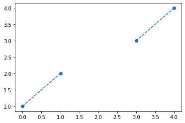

```python
x=[1,2,None,3,4]
plt.plot(x,'o--')
```

(예비학습끝)

```python
df.iloc[1:].set_index(('행정구역별','행정구역별')).stack().reset_index().query("level_1 == '비율'").set_index(('행정구역별','행정구역별')).iloc[:,1:].T.\
applymap(lambda x: float(x) if x!='-' else None)
```

| (행정구역별, 행정구역별) | 서울특별시 | 부산광역시 | 대구광역시 | 인천광역시 | 광주광역시 | 대전광역시 | 울산광역시 | 세종특별자치시 | 경기도 | 강원도 | 충청북도 | 충청남도 | 전라북도 | 전라남도 | 경상북도 | 경상남도 | 제주특별자치도 |
| --- | --- | --- | --- | --- | --- | --- | --- | --- | --- | --- | --- | --- | --- | --- | --- | --- | --- |
| 2000 | 5.4 | 6.0 | 5.9 | 5.4 | 5.6 | 5.5 | 4.0 | NaN | 5.7 | 9.3 | 9.1 | 11.2 | 10.3 | 11.9 | 10.7 | 8.4 | 8.0 |
| 2005 | 7.2 | 8.3 | 7.8 | 6.9 | 7.1 | 6.9 | 5.3 | NaN | 7.1 | 12.1 | 11.3 | 13.3 | 12.9 | 15.6 | 13.4 | 10.2 | 10.0 |
| 2010 | 9.7 | 11.3 | 10.0 | 8.6 | 9.0 | 8.7 | 6.8 | NaN | 8.7 | 14.8 | 13.2 | 14.9 | 15.2 | 18.3 | 15.6 | 11.8 | 12.2 |
| 2015 | 12.6 | 14.6 | 12.7 | 10.7 | 11.3 | 10.9 | 8.8 | 10.6 | 10.5 | 16.9 | 14.8 | 16.4 | 17.8 | 20.5 | 17.7 | 13.8 | 13.8 |
| 2021. 06 | 16.4 | 19.8 | 17.0 | 14.4 | 14.5 | 14.8 | 13.1 | 10.0 | 13.5 | 21.2 | 18.4 | 19.5 | 21.8 | 23.9 | 22.2 | 17.9 | 16.0 |

이제 그리자..

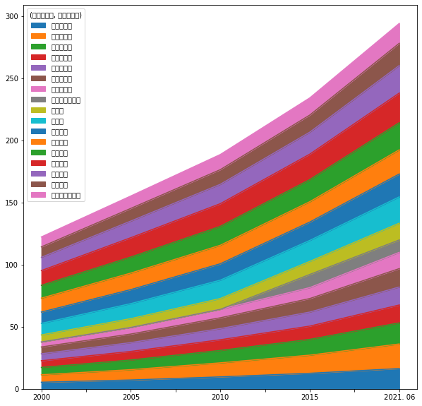

```python
warnings.filterwarnings("ignore")
df.iloc[1:].set_index(('행정구역별','행정구역별')).stack().reset_index().query("level_1 == '비율'").set_index(('행정구역별','행정구역별')).iloc[:,1:].T.\
applymap(lambda x: float(x) if x!='-' else None).\
plot.area(figsize=(10,10))
```

- 한글이 깨져서 나온다 $\to$ 고치는 방법이 있긴한데 그냥 포기함.

#### 예제2 (plotly)

`-` plotly로 그려보자. 우선 타이디한 자료까지 만들자.

```python
df.iloc[1:].set_index(('행정구역별','행정구역별')).stack().applymap(lambda x: float(x) if x!='-' else None).stack().reset_index()
```

|  | (행정구역별, 행정구역별) | level_1 | level_2 | 0 |
| --- | --- | --- | --- | --- |
| 0 | 서울특별시 | 비율 | 2000 | 5.4 |
| 1 | 서울특별시 | 비율 | 2005 | 7.2 |
| 2 | 서울특별시 | 비율 | 2010 | 9.7 |
| 3 | 서울특별시 | 비율 | 2015 | 12.6 |
| 4 | 서울특별시 | 비율 | 2021. 06 | 16.4 |
| ... | ... | ... | ... | ... |
| 159 | 제주특별자치도 | 인구 | 2000 | 43334.0 |
| 160 | 제주특별자치도 | 인구 | 2005 | 55795.0 |
| 161 | 제주특별자치도 | 인구 | 2010 | 69641.0 |
| 162 | 제주특별자치도 | 인구 | 2015 | 85893.0 |
| 163 | 제주특별자치도 | 인구 | 2021. 06 | 108118.0 |

164 rows × 4 columns

```python
_df = _
_df
```

|  | (행정구역별, 행정구역별) | level_1 | level_2 | 0 |
| --- | --- | --- | --- | --- |
| 0 | 서울특별시 | 비율 | 2000 | 5.4 |
| 1 | 서울특별시 | 비율 | 2005 | 7.2 |
| 2 | 서울특별시 | 비율 | 2010 | 9.7 |
| 3 | 서울특별시 | 비율 | 2015 | 12.6 |
| 4 | 서울특별시 | 비율 | 2021. 06 | 16.4 |
| ... | ... | ... | ... | ... |
| 159 | 제주특별자치도 | 인구 | 2000 | 43334.0 |
| 160 | 제주특별자치도 | 인구 | 2005 | 55795.0 |
| 161 | 제주특별자치도 | 인구 | 2010 | 69641.0 |
| 162 | 제주특별자치도 | 인구 | 2015 | 85893.0 |
| 163 | 제주특별자치도 | 인구 | 2021. 06 | 108118.0 |

164 rows × 4 columns

`-` 이름을 바꾸자

```python
_df.columns=['city','type','year','value']
_df
```

|  | city | type | year | value |
| --- | --- | --- | --- | --- |
| 0 | 서울특별시 | 비율 | 2000 | 5.4 |
| 1 | 서울특별시 | 비율 | 2005 | 7.2 |
| 2 | 서울특별시 | 비율 | 2010 | 9.7 |
| 3 | 서울특별시 | 비율 | 2015 | 12.6 |
| 4 | 서울특별시 | 비율 | 2021. 06 | 16.4 |
| ... | ... | ... | ... | ... |
| 159 | 제주특별자치도 | 인구 | 2000 | 43334.0 |
| 160 | 제주특별자치도 | 인구 | 2005 | 55795.0 |
| 161 | 제주특별자치도 | 인구 | 2010 | 69641.0 |
| 162 | 제주특별자치도 | 인구 | 2015 | 85893.0 |
| 163 | 제주특별자치도 | 인구 | 2021. 06 | 108118.0 |

164 rows × 4 columns

`-` 더이상 안건드려도 된다.

```python
fig = _df.query('type == "인구"').plot.area(backend='plotly',x='year',y='value',color='city')
show(fig)
```

[interactive chart not shown]

- 행복함